# ANCOVA test for textual (engajamento no textual)

Geiser C. Challco geiser@alumni.usp.br

- Descriptive Statistics of Initial Data
- Checking of Assumptions
  - Assumption: Normality distribution of data
  - Assumption: Homogeneity of data distribution
- Computation of ANCOVA test and Pairwise Comparison
  - ANCOVA tests for one factor
  - ANCOVA tests for two factors
  - ANCOVA tests for grupo=“Experimental”
  - Pairwise comparisons for one factor
    - factor: **grupo**
    - factor: **genero**
    - factor: **idade**
    - factor: **zona.participante**
    - factor: **escola**
    - factor: **zona.escola**
  - Pairwise comparisons for two factors
    - factores: **grupo:genero**
    - factores: **grupo:idade**
    - factores: **grupo:zona.participante**
    - factores: **grupo:escola**
    - factores: **grupo:zona.escola**
  - Pairwise comparisons for grupo=“Experimental”
    - factores: **grupo=“Experimental”:monitor**
    - factores: **grupo=“Experimental”:monitor.genero**
    - factores: **grupo=“Experimental”:monitor.area**
    - factores: **grupo=“Experimental”:monitor.formacao**
    - factores: **grupo=“Experimental”:monitor.experiencia**

**NOTE**

- Teste ANCOVA para determinar se houve diferenças significativas em referência ao engajamento no textual (medido como estado de fluxo).
- ANCOVA test to determine whether there were significant differences in reference to engagement in textual (measured as flow state).

# Descriptive Statistics of Initial Data

| grupo | genero | idade | zona.participante | escola | zona.escola | variable | n | mean | median | min | max | sd | se | ci | iqr |
| --- | --- | --- | --- | --- | --- | --- | --- | --- | --- | --- | --- | --- | --- | --- | --- |
| Controle | F |  |  |  |  | fss.textual | 59 | 3.542 | 3.556 | 2.222 | 4.778 | 0.605 | 0.079 | 0.158 | 0.722 |
| Controle | M |  |  |  |  | fss.textual | 62 | 3.439 | 3.444 | 2.444 | 5.000 | 0.551 | 0.070 | 0.140 | 0.750 |
| Experimental | F |  |  |  |  | fss.textual | 57 | 3.698 | 3.667 | 2.222 | 5.000 | 0.568 | 0.075 | 0.151 | 0.778 |
| Experimental | M |  |  |  |  | fss.textual | 74 | 3.391 | 3.333 | 1.750 | 4.667 | 0.583 | 0.068 | 0.135 | 0.778 |
| Controle | F |  |  |  |  | dfs.textual | 59 | 3.536 | 3.556 | 2.222 | 4.556 | 0.593 | 0.077 | 0.155 | 0.889 |
| Controle | M |  |  |  |  | dfs.textual | 62 | 3.490 | 3.444 | 2.000 | 4.667 | 0.537 | 0.068 | 0.136 | 0.778 |
| Experimental | F |  |  |  |  | dfs.textual | 57 | 3.545 | 3.556 | 2.222 | 4.714 | 0.574 | 0.076 | 0.152 | 0.667 |
| Experimental | M |  |  |  |  | dfs.textual | 74 | 3.404 | 3.278 | 2.444 | 4.778 | 0.549 | 0.064 | 0.127 | 0.778 |
| Controle |  | 10y |  |  |  | fss.textual | 23 | 3.580 | 3.556 | 2.222 | 4.778 | 0.644 | 0.134 | 0.279 | 1.000 |
| Controle |  | 11y |  |  |  | fss.textual | 64 | 3.555 | 3.556 | 2.222 | 5.000 | 0.581 | 0.073 | 0.145 | 0.806 |
| Controle |  | 12y |  |  |  | fss.textual | 18 | 3.351 | 3.222 | 2.667 | 4.556 | 0.578 | 0.136 | 0.287 | 0.788 |
| Controle |  | 13y |  |  |  | fss.textual | 7 | 3.190 | 3.222 | 2.778 | 3.444 | 0.210 | 0.079 | 0.194 | 0.111 |
| Controle |  | 14y |  |  |  | fss.textual | 1 | 3.556 | 3.556 | 3.556 | 3.556 |  |  |  | 0.000 |
| Controle |  | 15y |  |  |  | fss.textual | 1 | 2.889 | 2.889 | 2.889 | 2.889 |  |  |  | 0.000 |
| Controle |  | 16y |  |  |  | fss.textual | 1 | 2.889 | 2.889 | 2.889 | 2.889 |  |  |  | 0.000 |
| Controle |  |  |  |  |  | fss.textual | 6 | 3.389 | 3.444 | 2.667 | 4.111 | 0.543 | 0.222 | 0.570 | 0.722 |
| Experimental |  | 10y |  |  |  | fss.textual | 24 | 3.524 | 3.444 | 2.667 | 4.444 | 0.508 | 0.104 | 0.215 | 0.694 |
| Experimental |  | 11y |  |  |  | fss.textual | 79 | 3.590 | 3.556 | 2.000 | 5.000 | 0.586 | 0.066 | 0.131 | 0.556 |
| Experimental |  | 12y |  |  |  | fss.textual | 16 | 3.618 | 3.722 | 2.556 | 4.333 | 0.581 | 0.145 | 0.310 | 0.778 |
| Experimental |  | 13y |  |  |  | fss.textual | 9 | 2.799 | 2.889 | 1.750 | 3.333 | 0.441 | 0.147 | 0.339 | 0.111 |
| Experimental |  | 14y |  |  |  | fss.textual | 1 | 4.444 | 4.444 | 4.444 | 4.444 |  |  |  | 0.000 |
| Experimental |  |  |  |  |  | fss.textual | 2 | 3.000 | 3.000 | 2.889 | 3.111 | 0.157 | 0.111 | 1.412 | 0.111 |
| Controle |  | 10y |  |  |  | dfs.textual | 23 | 3.572 | 3.778 | 2.444 | 4.444 | 0.546 | 0.114 | 0.236 | 0.833 |
| Controle |  | 11y |  |  |  | dfs.textual | 64 | 3.599 | 3.667 | 2.222 | 4.667 | 0.557 | 0.070 | 0.139 | 0.778 |
| Controle |  | 12y |  |  |  | dfs.textual | 18 | 3.367 | 3.292 | 2.667 | 4.556 | 0.513 | 0.121 | 0.255 | 0.806 |
| Controle |  | 13y |  |  |  | dfs.textual | 7 | 3.450 | 3.444 | 2.556 | 4.375 | 0.574 | 0.217 | 0.531 | 0.444 |
| Controle |  | 14y |  |  |  | dfs.textual | 1 | 3.778 | 3.778 | 3.778 | 3.778 |  |  |  | 0.000 |
| Controle |  | 15y |  |  |  | dfs.textual | 1 | 2.000 | 2.000 | 2.000 | 2.000 |  |  |  | 0.000 |
| Controle |  | 16y |  |  |  | dfs.textual | 1 | 3.444 | 3.444 | 3.444 | 3.444 |  |  |  | 0.000 |
| Controle |  |  |  |  |  | dfs.textual | 6 | 3.093 | 2.944 | 2.667 | 3.889 | 0.463 | 0.189 | 0.486 | 0.500 |
| Experimental |  | 10y |  |  |  | dfs.textual | 24 | 3.356 | 3.222 | 2.333 | 4.778 | 0.648 | 0.132 | 0.274 | 0.806 |
| Experimental |  | 11y |  |  |  | dfs.textual | 79 | 3.535 | 3.556 | 2.222 | 4.714 | 0.549 | 0.062 | 0.123 | 0.722 |
| Experimental |  | 12y |  |  |  | dfs.textual | 16 | 3.486 | 3.556 | 2.444 | 4.333 | 0.571 | 0.143 | 0.304 | 1.028 |
| Experimental |  | 13y |  |  |  | dfs.textual | 9 | 3.136 | 3.000 | 2.778 | 3.667 | 0.337 | 0.112 | 0.259 | 0.556 |
| Experimental |  | 14y |  |  |  | dfs.textual | 1 | 3.222 | 3.222 | 3.222 | 3.222 |  |  |  | 0.000 |
| Experimental |  |  |  |  |  | dfs.textual | 2 | 3.444 | 3.444 | 3.000 | 3.889 | 0.629 | 0.444 | 5.647 | 0.444 |
| Controle |  |  | Urbana |  |  | fss.textual | 53 | 3.553 | 3.556 | 2.222 | 5.000 | 0.589 | 0.081 | 0.162 | 0.667 |
| Controle |  |  | Rural |  |  | fss.textual | 42 | 3.370 | 3.333 | 2.444 | 4.778 | 0.576 | 0.089 | 0.179 | 0.750 |
| Controle |  |  |  |  |  | fss.textual | 26 | 3.551 | 3.611 | 2.222 | 4.556 | 0.548 | 0.108 | 0.221 | 0.583 |
| Experimental |  |  | Urbana |  |  | fss.textual | 49 | 3.537 | 3.556 | 1.750 | 4.778 | 0.549 | 0.078 | 0.158 | 0.667 |
| Experimental |  |  | Rural |  |  | fss.textual | 52 | 3.546 | 3.444 | 2.000 | 5.000 | 0.639 | 0.089 | 0.178 | 1.139 |
| Experimental |  |  |  |  |  | fss.textual | 30 | 3.467 | 3.500 | 2.222 | 4.556 | 0.603 | 0.110 | 0.225 | 0.889 |
| Controle |  |  | Urbana |  |  | dfs.textual | 53 | 3.535 | 3.500 | 2.000 | 4.667 | 0.596 | 0.082 | 0.164 | 0.889 |
| Controle |  |  | Rural |  |  | dfs.textual | 42 | 3.514 | 3.500 | 2.444 | 4.556 | 0.573 | 0.088 | 0.179 | 0.889 |
| Controle |  |  |  |  |  | dfs.textual | 26 | 3.464 | 3.444 | 2.444 | 4.111 | 0.492 | 0.096 | 0.199 | 0.750 |
| Experimental |  |  | Urbana |  |  | dfs.textual | 49 | 3.436 | 3.444 | 2.333 | 4.714 | 0.569 | 0.081 | 0.163 | 1.000 |
| Experimental |  |  | Rural |  |  | dfs.textual | 52 | 3.480 | 3.444 | 2.429 | 4.778 | 0.595 | 0.083 | 0.166 | 0.889 |
| Experimental |  |  |  |  |  | dfs.textual | 30 | 3.486 | 3.563 | 2.222 | 4.444 | 0.506 | 0.092 | 0.189 | 0.667 |
| Controle |  |  |  | E1 |  | fss.textual | 11 | 3.465 | 3.444 | 2.889 | 4.444 | 0.516 | 0.156 | 0.347 | 0.556 |
| Controle |  |  |  | E2 |  | fss.textual | 23 | 3.497 | 3.500 | 2.222 | 5.000 | 0.731 | 0.152 | 0.316 | 1.000 |
| Controle |  |  |  | E3 |  | fss.textual | 14 | 3.348 | 3.333 | 2.556 | 4.222 | 0.410 | 0.110 | 0.237 | 0.306 |
| Controle |  |  |  | E4 |  | fss.textual | 16 | 3.331 | 3.333 | 2.444 | 4.111 | 0.513 | 0.128 | 0.273 | 0.552 |
| Controle |  |  |  | E5 |  | fss.textual | 46 | 3.556 | 3.556 | 2.556 | 4.778 | 0.587 | 0.087 | 0.174 | 1.083 |
| Controle |  |  |  | E6 |  | fss.textual | 11 | 3.626 | 3.667 | 2.222 | 4.222 | 0.536 | 0.162 | 0.360 | 0.389 |
| Experimental |  |  |  | E1 |  | fss.textual | 10 | 4.003 | 3.889 | 3.333 | 5.000 | 0.596 | 0.189 | 0.426 | 0.896 |
| Experimental |  |  |  | E2 |  | fss.textual | 26 | 3.324 | 3.389 | 1.750 | 4.111 | 0.520 | 0.102 | 0.210 | 0.528 |
| Experimental |  |  |  | E3 |  | fss.textual | 14 | 3.440 | 3.389 | 2.000 | 4.333 | 0.690 | 0.184 | 0.398 | 1.111 |
| Experimental |  |  |  | E4 |  | fss.textual | 14 | 3.603 | 3.556 | 2.778 | 4.444 | 0.558 | 0.149 | 0.322 | 1.028 |
| Experimental |  |  |  | E5 |  | fss.textual | 54 | 3.503 | 3.556 | 2.222 | 4.667 | 0.582 | 0.079 | 0.159 | 0.861 |
| Experimental |  |  |  | E6 |  | fss.textual | 13 | 3.658 | 3.778 | 2.556 | 4.556 | 0.582 | 0.161 | 0.352 | 0.556 |
| Controle |  |  |  | E1 |  | dfs.textual | 11 | 3.278 | 3.444 | 2.000 | 4.111 | 0.625 | 0.188 | 0.420 | 0.750 |
| Controle |  |  |  | E2 |  | dfs.textual | 23 | 3.536 | 3.556 | 2.667 | 4.667 | 0.568 | 0.118 | 0.246 | 0.889 |
| Controle |  |  |  | E3 |  | dfs.textual | 14 | 3.588 | 3.667 | 2.778 | 4.444 | 0.544 | 0.145 | 0.314 | 0.740 |
| Controle |  |  |  | E4 |  | dfs.textual | 16 | 3.512 | 3.444 | 2.778 | 4.375 | 0.386 | 0.096 | 0.205 | 0.472 |
| Controle |  |  |  | E5 |  | dfs.textual | 46 | 3.492 | 3.472 | 2.222 | 4.556 | 0.644 | 0.095 | 0.191 | 1.083 |
| Controle |  |  |  | E6 |  | dfs.textual | 11 | 3.686 | 3.875 | 3.000 | 4.111 | 0.350 | 0.106 | 0.235 | 0.500 |
| Experimental |  |  |  | E1 |  | dfs.textual | 10 | 3.510 | 3.500 | 2.750 | 4.222 | 0.470 | 0.149 | 0.336 | 0.556 |
| Experimental |  |  |  | E2 |  | dfs.textual | 26 | 3.415 | 3.444 | 2.444 | 4.222 | 0.460 | 0.090 | 0.186 | 0.639 |
| Experimental |  |  |  | E3 |  | dfs.textual | 14 | 3.531 | 3.667 | 2.444 | 4.556 | 0.730 | 0.195 | 0.422 | 1.344 |
| Experimental |  |  |  | E4 |  | dfs.textual | 14 | 3.635 | 3.556 | 2.889 | 4.444 | 0.579 | 0.155 | 0.334 | 1.083 |
| Experimental |  |  |  | E5 |  | dfs.textual | 54 | 3.414 | 3.444 | 2.222 | 4.778 | 0.604 | 0.082 | 0.165 | 0.778 |
| Experimental |  |  |  | E6 |  | dfs.textual | 13 | 3.488 | 3.571 | 2.778 | 4.222 | 0.453 | 0.126 | 0.274 | 0.667 |
| Controle |  |  |  |  | Urbana | fss.textual | 80 | 3.526 | 3.556 | 2.222 | 5.000 | 0.617 | 0.069 | 0.137 | 1.028 |
| Controle |  |  |  |  | Rural | fss.textual | 41 | 3.416 | 3.444 | 2.222 | 4.222 | 0.492 | 0.077 | 0.155 | 0.444 |
| Experimental |  |  |  |  | Urbana | fss.textual | 90 | 3.506 | 3.500 | 1.750 | 5.000 | 0.592 | 0.062 | 0.124 | 0.778 |
| Experimental |  |  |  |  | Rural | fss.textual | 41 | 3.565 | 3.556 | 2.000 | 4.556 | 0.605 | 0.094 | 0.191 | 1.000 |
| Controle |  |  |  |  | Urbana | dfs.textual | 80 | 3.476 | 3.444 | 2.000 | 4.667 | 0.619 | 0.069 | 0.138 | 1.000 |
| Controle |  |  |  |  | Rural | dfs.textual | 41 | 3.585 | 3.556 | 2.778 | 4.444 | 0.433 | 0.068 | 0.137 | 0.556 |
| Experimental |  |  |  |  | Urbana | dfs.textual | 90 | 3.425 | 3.444 | 2.222 | 4.778 | 0.548 | 0.058 | 0.115 | 0.778 |
| Experimental |  |  |  |  | Rural | dfs.textual | 41 | 3.553 | 3.571 | 2.444 | 4.556 | 0.590 | 0.092 | 0.186 | 1.000 |

# Checking of Assumptions

## Assumption: Normality distribution of data

| var | n | skewness | kurtosis | symmetry | statistic | method | p | p.signif | normality |
| --- | --- | --- | --- | --- | --- | --- | --- | --- | --- |
| fss.textual | 252 | 0.0374846 | 0.2812193 | YES | 1.3278767 | D’Agostino | 0.5148198 | ns | - |
| fss.textual | 244 | -0.0481818 | 0.3726694 | YES | 1.9103011 | D’Agostino | 0.3847542 | ns | - |
| fss.textual | 196 | 0.1564001 | 0.5017399 | YES | 3.2506413 | D’Agostino | 0.1968485 | ns | QQ |
| fss.textual | 252 | -0.0511290 | 0.0524088 | YES | 0.3345749 | D’Agostino | 0.8459564 | ns | - |
| fss.textual | 252 | 0.0144262 | 0.1462362 | YES | 0.5736641 | D’Agostino | 0.7506378 | ns | - |

## Assumption: Homogeneity of data distribution

| var | method | formula | n | DFn.df1 | DFd.df2 | statistic | p | p.signif |
| --- | --- | --- | --- | --- | --- | --- | --- | --- |
| fss.textual | Levene’s test | `.res`~`grupo`*`genero` | 252 | 3 | 248 | 0.4330174 | 0.7295443 | ns |
| fss.textual | Anova’s slopes | `.res`~`grupo`*`genero` | 252 | 3 | 244 | 0.5130000 | 0.6740000 | ns |
| fss.textual | Levene’s test | `.res`~`grupo`*`idade` | 244 | 11 | 232 | 0.9983121 | 0.4486560 | ns |
| fss.textual | Anova’s slopes | `.res`~`grupo`*`idade` | 244 | 7 | 224 | 0.8780000 | 0.5250000 | ns |
| fss.textual | Levene’s test | `.res`~`grupo`*`zona.participante` | 196 | 3 | 192 | 0.7058107 | 0.5496284 | ns |
| fss.textual | Anova’s slopes | `.res`~`grupo`*`zona.participante` | 196 | 3 | 188 | 0.1020000 | 0.9590000 | ns |
| fss.textual | Levene’s test | `.res`~`grupo`*`escola` | 252 | 11 | 240 | 1.1287046 | 0.3393361 | ns |
| fss.textual | Anova’s slopes | `.res`~`grupo`*`escola` | 252 | 11 | 228 | 0.6310000 | 0.8010000 | ns |
| fss.textual | Levene’s test | `.res`~`grupo`*`zona.escola` | 252 | 3 | 248 | 0.9803941 | 0.4025824 | ns |
| fss.textual | Anova’s slopes | `.res`~`grupo`*`zona.escola` | 252 | 3 | 244 | 0.5490000 | 0.6500000 | ns |

# Computation of ANCOVA test and Pairwise Comparison

## ANCOVA tests for one factor

|  | Effect | DFn | DFd | SSn | SSd | F | p | ges | p<.05 |
| --- | --- | --- | --- | --- | --- | --- | --- | --- | --- |
| 1 | dfs.textual | 1 | 249 | 12.998 | 72.999 | 44.338 | <0.001 | 0.151 | * |
| 2 | grupo | 1 | 249 | 0.190 | 72.999 | 0.648 | 0.422 | 0.003 |  |
| 4 | genero | 1 | 249 | 1.734 | 71.454 | 6.043 | 0.015 | 0.024 | * |
| 6 | idade | 6 | 236 | 4.471 | 67.089 | 2.621 | 0.018 | 0.062 | * |
| 8 | zona.participante | 1 | 193 | 0.322 | 57.459 | 1.081 | 0.3 | 0.006 |  |
| 10 | escola | 5 | 245 | 2.939 | 70.250 | 2.050 | 0.072 | 0.040 |  |
| 12 | zona.escola | 1 | 249 | 0.305 | 72.883 | 1.042 | 0.308 | 0.004 |  |

## ANCOVA tests for two factors

|  | Effect | DFn | DFd | SSn | SSd | F | p | ges | p<.05 |
| --- | --- | --- | --- | --- | --- | --- | --- | --- | --- |
| 1 | dfs.textual | 1 | 247 | 11.888 | 70.768 | 41.492 | <0.001 | 0.144 | * |
| 4 | grupo:genero | 1 | 247 | 0.435 | 70.768 | 1.519 | 0.219 | 0.006 |  |
| 8 | grupo:idade | 4 | 231 | 1.210 | 65.643 | 1.064 | 0.375 | 0.018 |  |
| 12 | grupo:zona.participante | 1 | 191 | 0.334 | 56.610 | 1.126 | 0.29 | 0.006 |  |
| 16 | grupo:escola | 5 | 239 | 1.576 | 68.485 | 1.100 | 0.361 | 0.022 |  |
| 20 | grupo:zona.escola | 1 | 247 | 0.358 | 72.346 | 1.224 | 0.27 | 0.005 |  |

## ANCOVA tests for grupo=“Experimental”

|  | Effect | DFn | DFd | SSn | SSd | F | p | ges | p<.05 |
| --- | --- | --- | --- | --- | --- | --- | --- | --- | --- |
| 1 | dfs.textual | 1 | 111 | 6.389 | 30.681 | 23.114 | <0.001 | 0.172 | * |
| 2 | monitor | 9 | 111 | 4.185 | 30.681 | 1.682 | 0.102 | 0.120 |  |
| 4 | monitor.genero | 1 | 119 | 1.465 | 33.400 | 5.221 | 0.024 | 0.042 | * |
| 6 | monitor.area | 8 | 112 | 3.284 | 31.581 | 1.456 | 0.181 | 0.094 |  |
| 8 | monitor.formacao | 2 | 118 | 0.150 | 34.716 | 0.254 | 0.776 | 0.004 |  |
| 10 | monitor.experiencia | 1 | 119 | 0.216 | 34.649 | 0.743 | 0.39 | 0.006 |  |

## Pairwise comparisons for one factor

### factor: **grupo**

| var | grupo | n | M (pre) | SE (pre) | M (unadj) | SE (unadj) | M (adj) | SE (adj) |
| --- | --- | --- | --- | --- | --- | --- | --- | --- |
| fss.textual | Controle | 121 | 3.513 | 0.051 | 3.489 | 0.053 | 3.479 | 0.049 |
| fss.textual | Experimental | 131 | 3.465 | 0.049 | 3.525 | 0.052 | 3.534 | 0.047 |

| .y. | group1 | group2 | estimate | conf.low | conf.high | se | statistic | p | p.adj | p.adj.signif |
| --- | --- | --- | --- | --- | --- | --- | --- | --- | --- | --- |
| fss.textual | Controle | Experimental | -0.055 | -0.190 | 0.080 | 0.068 | -0.805 | 0.422 | 0.422 | ns |
| dfs.textual | Controle | Experimental | 0.048 | -0.092 | 0.187 | 0.071 | 0.670 | 0.503 | 0.503 | ns |

| .y. | grupo | group1 | group2 | estimate | conf.low | conf.high | se | statistic | p | p.adj | p.adj.signif |
| --- | --- | --- | --- | --- | --- | --- | --- | --- | --- | --- | --- |
| flow.textual | Controle | pre | pos | 0.023 | -0.122 | 0.169 | 0.074 | 0.318 | 0.751 | 0.751 | ns |
| flow.textual | Experimental | pre | pos | -0.060 | -0.199 | 0.080 | 0.071 | -0.842 | 0.400 | 0.400 | ns |

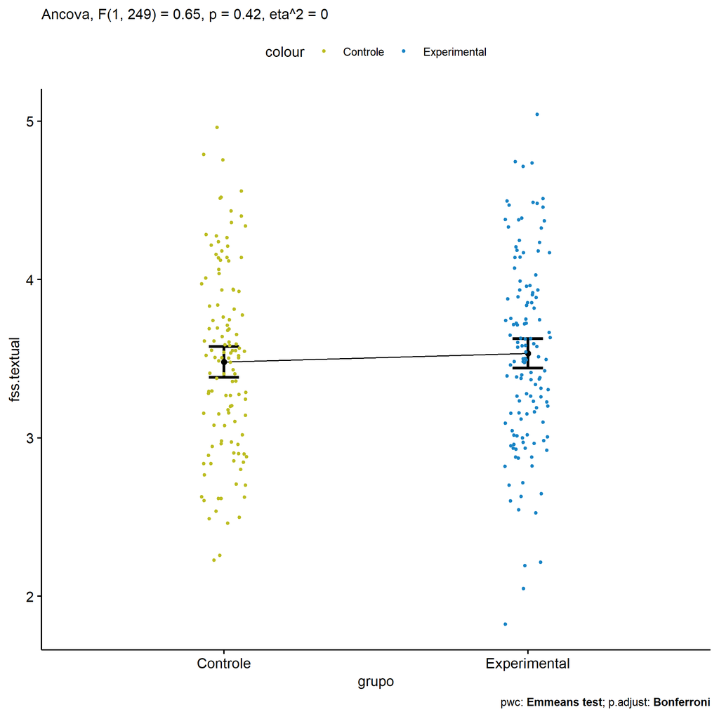

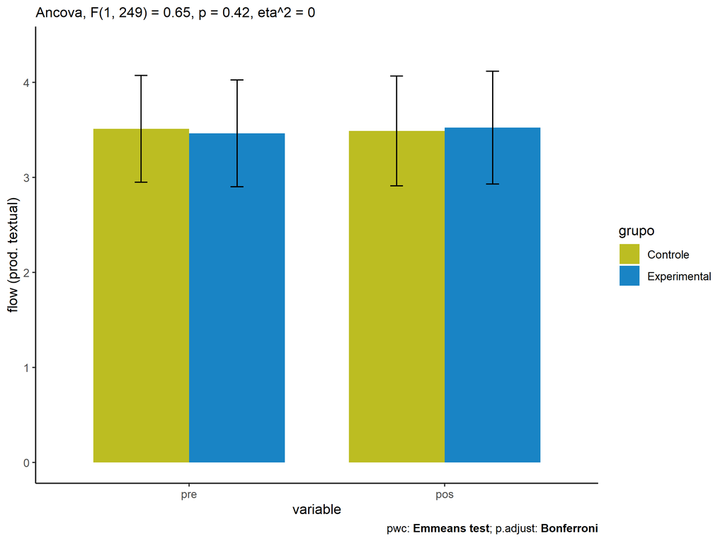

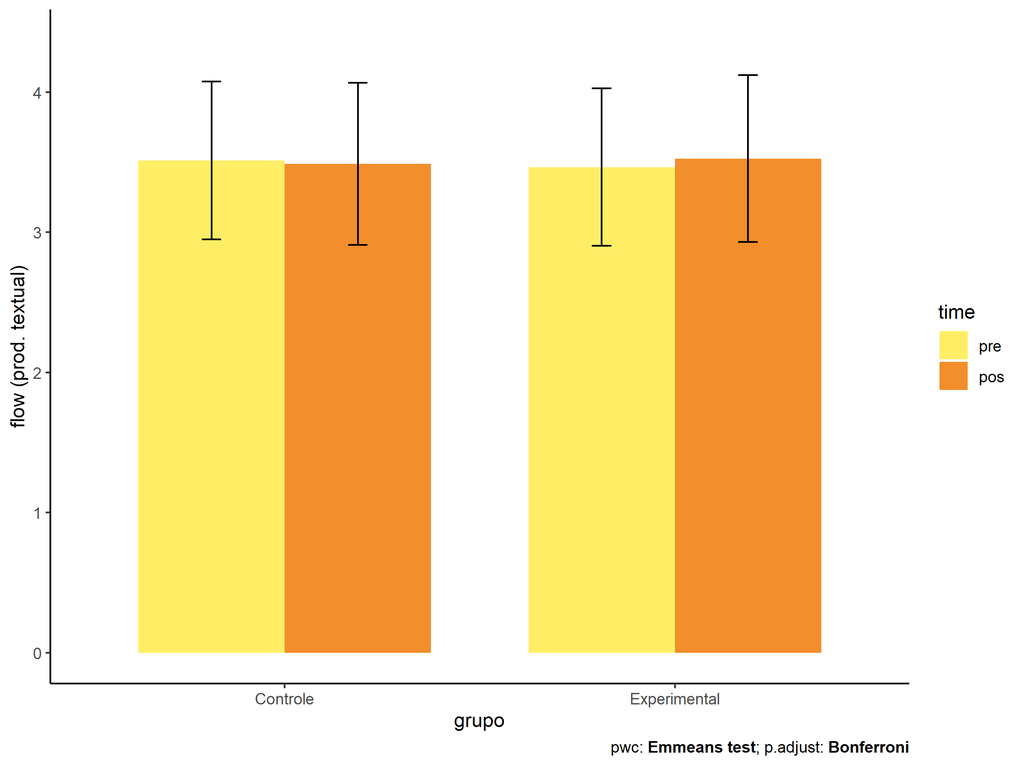

### factor: **genero**

| var | genero | n | M (pre) | SE (pre) | M (unadj) | SE (unadj) | M (adj) | SE (adj) |
| --- | --- | --- | --- | --- | --- | --- | --- | --- |
| fss.textual | F | 116 | 3.541 | 0.054 | 3.618 | 0.055 | 3.598 | 0.050 |
| fss.textual | M | 136 | 3.443 | 0.047 | 3.413 | 0.049 | 3.431 | 0.046 |

| .y. | group1 | group2 | estimate | conf.low | conf.high | se | statistic | p | p.adj | p.adj.signif |
| --- | --- | --- | --- | --- | --- | --- | --- | --- | --- | --- |
| fss.textual | F | M | 0.167 | 0.033 | 0.301 | 0.068 | 2.458 | 0.015 | 0.015 | * |
| dfs.textual | F | M | 0.098 | -0.042 | 0.237 | 0.071 | 1.378 | 0.169 | 0.169 | ns |

| .y. | genero | group1 | group2 | estimate | conf.low | conf.high | se | statistic | p | p.adj | p.adj.signif |
| --- | --- | --- | --- | --- | --- | --- | --- | --- | --- | --- | --- |
| flow.textual | F | pre | pos | -0.078 | -0.225 | 0.069 | 0.075 | -1.041 | 0.298 | 0.298 | ns |
| flow.textual | M | pre | pos | 0.030 | -0.106 | 0.165 | 0.069 | 0.430 | 0.668 | 0.668 | ns |

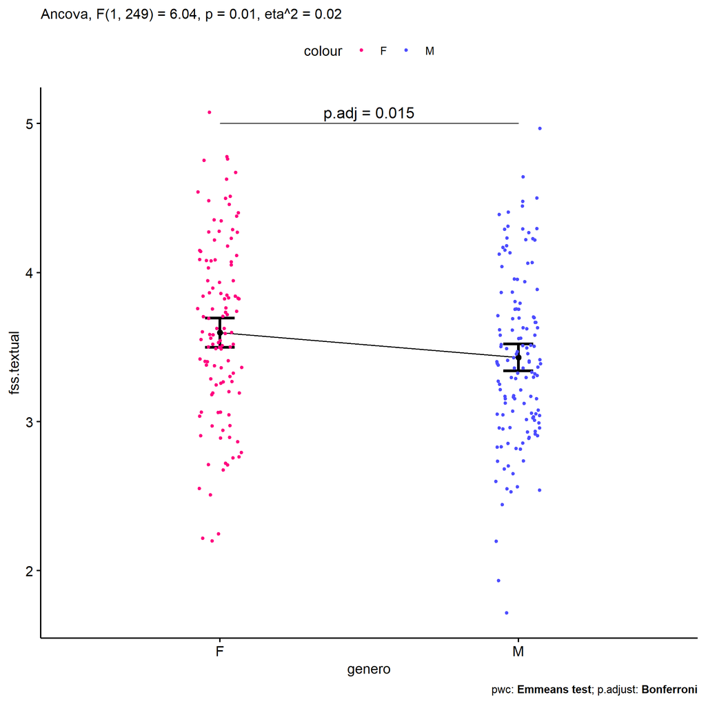

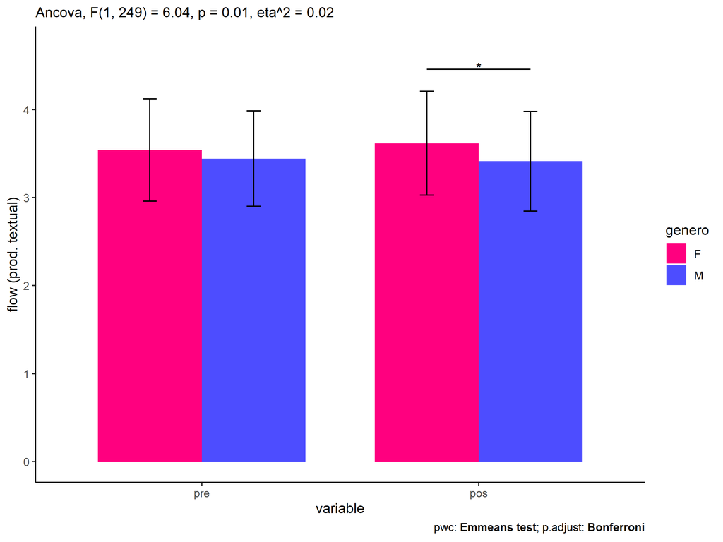

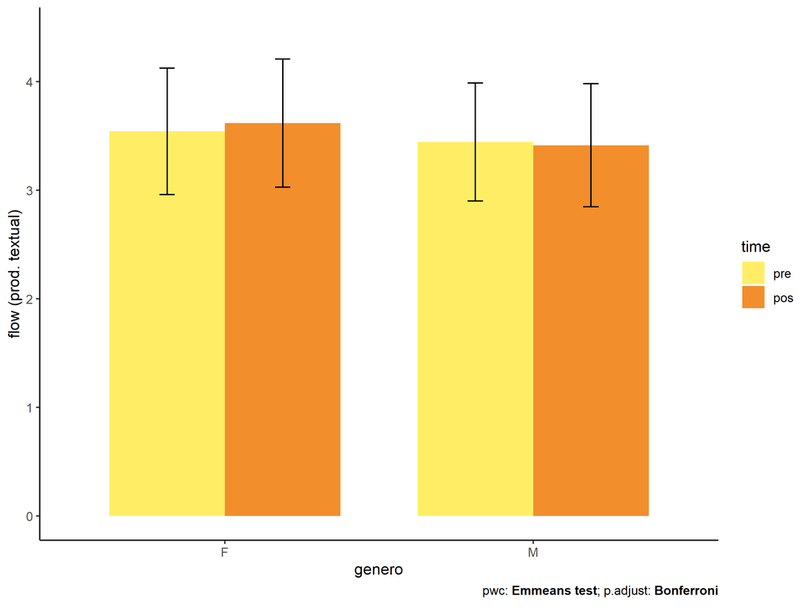

### factor: **idade**

| var | idade | n | M (pre) | SE (pre) | M (unadj) | SE (unadj) | M (adj) | SE (adj) |
| --- | --- | --- | --- | --- | --- | --- | --- | --- |
| fss.textual | 10y | 47 | 3.462 | 0.088 | 3.551 | 0.084 | 3.568 | 0.078 |
| fss.textual | 11y | 143 | 3.564 | 0.046 | 3.574 | 0.049 | 3.552 | 0.045 |
| fss.textual | 12y | 34 | 3.423 | 0.092 | 3.477 | 0.101 | 3.508 | 0.091 |
| fss.textual | 13y | 16 | 3.273 | 0.117 | 2.970 | 0.101 | 3.058 | 0.134 |

| .y. | group1 | group2 | estimate | conf.low | conf.high | se | statistic | p | p.adj | p.adj.signif |
| --- | --- | --- | --- | --- | --- | --- | --- | --- | --- | --- |
| fss.textual | 10y | 11y | 0.016 | -0.161 | 0.192 | 0.090 | 0.174 | 0.862 | 1.000 | ns |
| fss.textual | 10y | 12y | 0.060 | -0.176 | 0.296 | 0.120 | 0.501 | 0.617 | 1.000 | ns |
| fss.textual | 10y | 13y | 0.510 | 0.205 | 0.814 | 0.154 | 3.300 | 0.001 | 0.007 | ** |
| fss.textual | 11y | 12y | 0.044 | -0.156 | 0.245 | 0.102 | 0.436 | 0.664 | 1.000 | ns |
| fss.textual | 11y | 13y | 0.494 | 0.215 | 0.772 | 0.141 | 3.494 | <0.001 | 0.003 | ** |
| fss.textual | 12y | 13y | 0.450 | 0.131 | 0.768 | 0.162 | 2.783 | 0.006 | 0.035 | * |
| dfs.textual | 10y | 11y | -0.102 | -0.286 | 0.082 | 0.093 | -1.092 | 0.276 | 1.000 | ns |
| dfs.textual | 10y | 12y | 0.039 | -0.207 | 0.285 | 0.125 | 0.310 | 0.757 | 1.000 | ns |
| dfs.textual | 10y | 13y | 0.188 | -0.128 | 0.505 | 0.161 | 1.171 | 0.243 | 1.000 | ns |
| dfs.textual | 11y | 12y | 0.141 | -0.068 | 0.349 | 0.106 | 1.329 | 0.185 | 1.000 | ns |
| dfs.textual | 11y | 13y | 0.290 | 0.002 | 0.578 | 0.146 | 1.982 | 0.049 | 0.292 | ns |
| dfs.textual | 12y | 13y | 0.149 | -0.182 | 0.481 | 0.168 | 0.887 | 0.376 | 1.000 | ns |

| .y. | idade | group1 | group2 | estimate | conf.low | conf.high | se | statistic | p | p.adj | p.adj.signif |
| --- | --- | --- | --- | --- | --- | --- | --- | --- | --- | --- | --- |
| flow.textual | 10y | pre | pos | -0.090 | -0.318 | 0.138 | 0.116 | -0.773 | 0.440 | 0.440 | ns |
| flow.textual | 11y | pre | pos | -0.011 | -0.142 | 0.120 | 0.067 | -0.164 | 0.870 | 0.870 | ns |
| flow.textual | 12y | pre | pos | -0.054 | -0.322 | 0.214 | 0.137 | -0.395 | 0.693 | 0.693 | ns |
| flow.textual | 13y | pre | pos | 0.303 | -0.088 | 0.694 | 0.199 | 1.521 | 0.129 | 0.129 | ns |

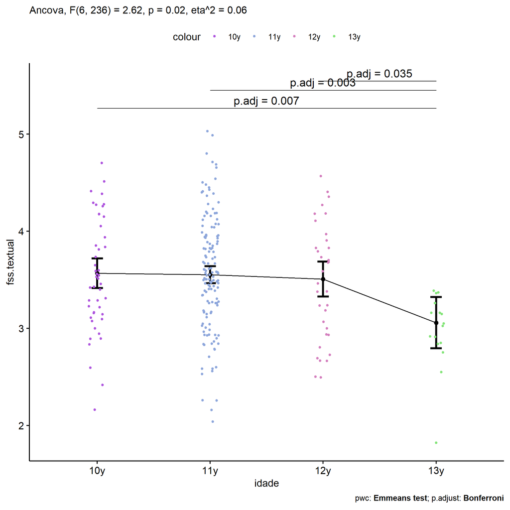

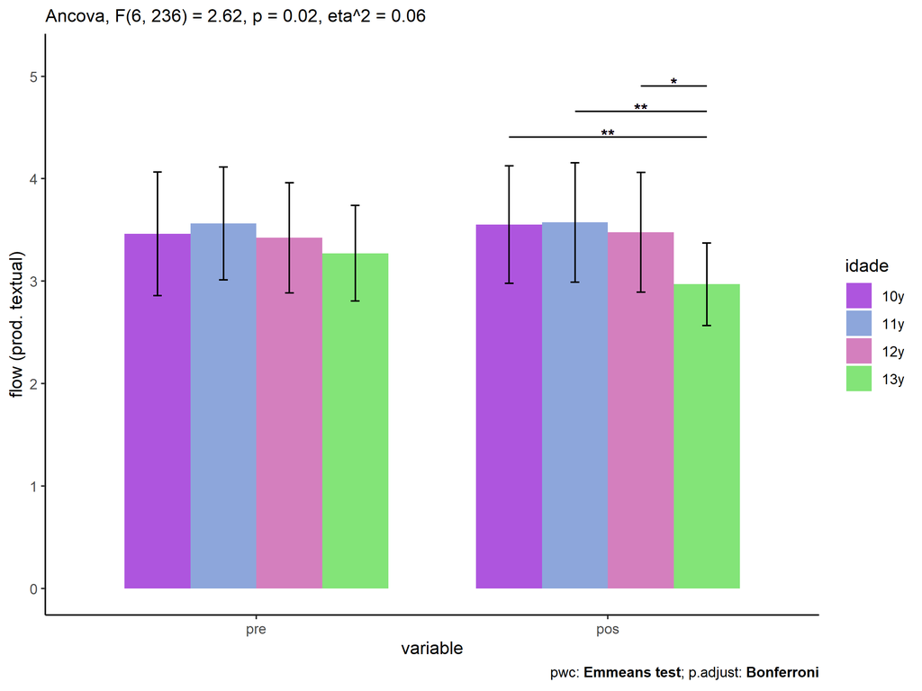

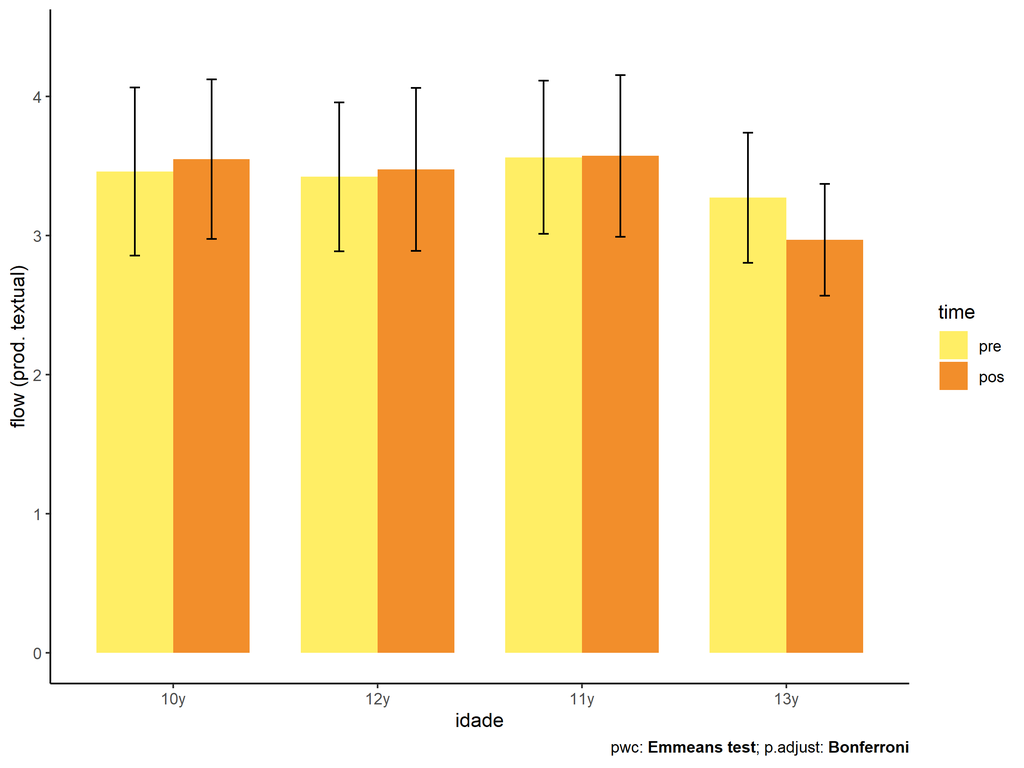

### factor: **zona.participante**

| var | zona.participante | n | M (pre) | SE (pre) | M (unadj) | SE (unadj) | M (adj) | SE (adj) |
| --- | --- | --- | --- | --- | --- | --- | --- | --- |
| fss.textual | Rural | 94 | 3.496 | 0.060 | 3.468 | 0.063 | 3.466 | 0.056 |
| fss.textual | Urbana | 102 | 3.487 | 0.058 | 3.545 | 0.056 | 3.547 | 0.054 |

| .y. | group1 | group2 | estimate | conf.low | conf.high | se | statistic | p | p.adj | p.adj.signif |
| --- | --- | --- | --- | --- | --- | --- | --- | --- | --- | --- |
| fss.textual | Urbana | Rural | 0.081 | -0.073 | 0.235 | 0.078 | 1.04 | 0.300 | 0.300 | ns |
| dfs.textual | Urbana | Rural | -0.008 | -0.172 | 0.156 | 0.083 | -0.10 | 0.921 | 0.921 | ns |

| .y. | zona.participante | group1 | group2 | estimate | conf.low | conf.high | se | statistic | p | p.adj | p.adj.signif |
| --- | --- | --- | --- | --- | --- | --- | --- | --- | --- | --- | --- |
| flow.textual | Urbana | pre | pos | -0.058 | -0.22 | 0.103 | 0.082 | -0.708 | 0.479 | 0.479 | ns |
| flow.textual | Rural | pre | pos | 0.028 | -0.14 | 0.196 | 0.086 | 0.327 | 0.744 | 0.744 | ns |

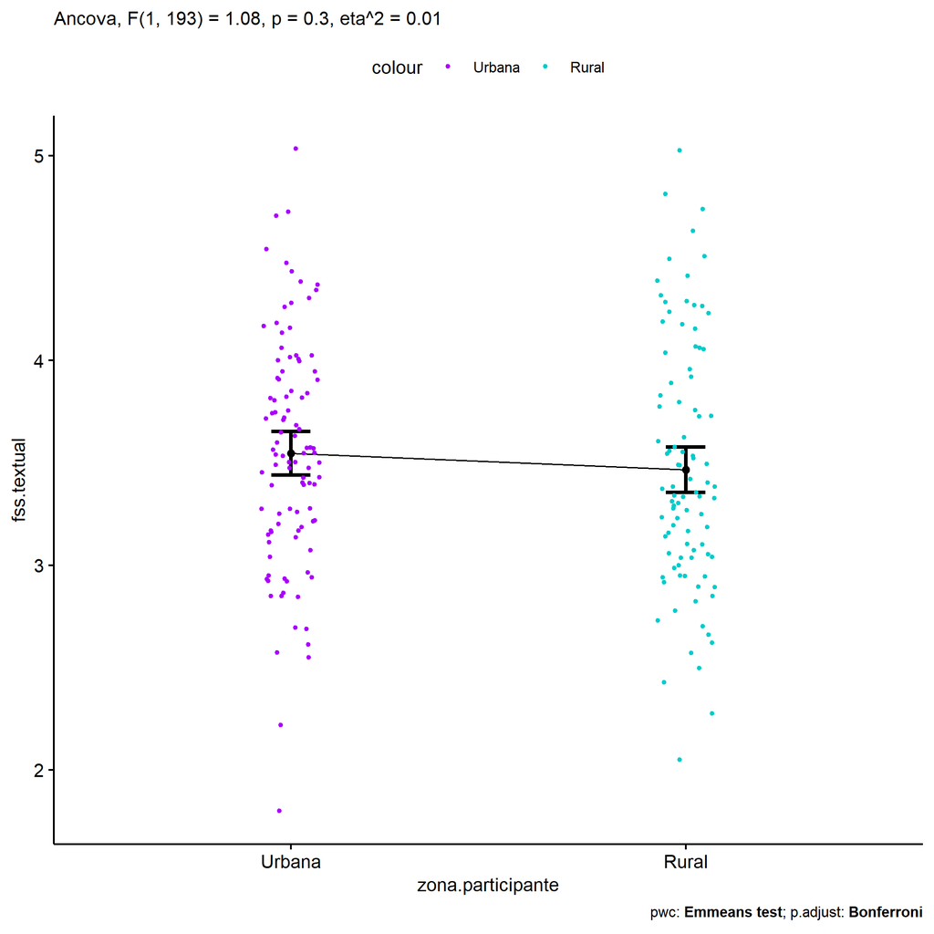

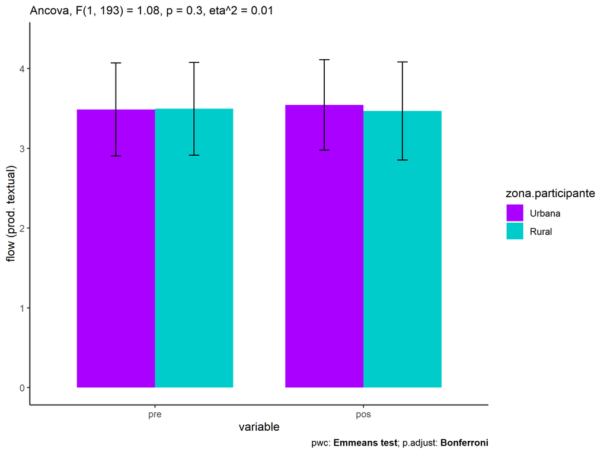

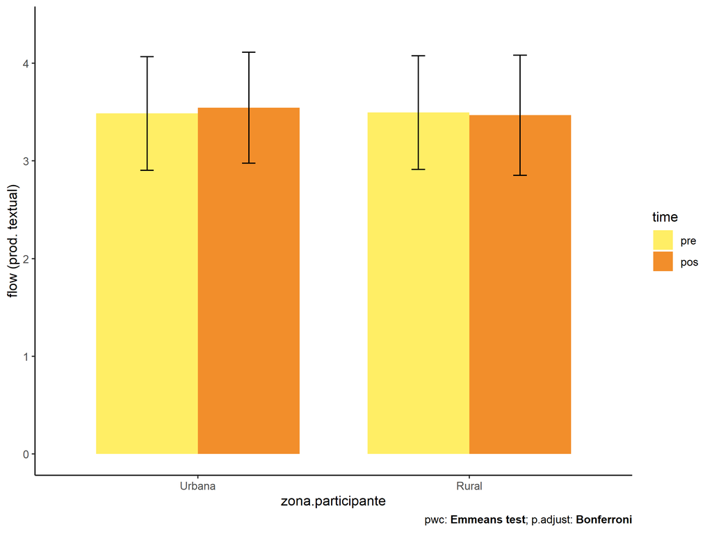

### factor: **escola**

| var | escola | n | M (pre) | SE (pre) | M (unadj) | SE (unadj) | M (adj) | SE (adj) |
| --- | --- | --- | --- | --- | --- | --- | --- | --- |
| fss.textual | E1 | 21 | 3.388 | 0.121 | 3.721 | 0.133 | 3.762 | 0.117 |
| fss.textual | E2 | 49 | 3.472 | 0.073 | 3.405 | 0.090 | 3.412 | 0.077 |
| fss.textual | E3 | 28 | 3.560 | 0.120 | 3.394 | 0.106 | 3.364 | 0.101 |
| fss.textual | E4 | 30 | 3.569 | 0.088 | 3.458 | 0.099 | 3.424 | 0.098 |
| fss.textual | E5 | 100 | 3.450 | 0.062 | 3.527 | 0.058 | 3.543 | 0.054 |
| fss.textual | E6 | 24 | 3.579 | 0.084 | 3.644 | 0.112 | 3.606 | 0.109 |

| .y. | group1 | group2 | estimate | conf.low | conf.high | se | statistic | p | p.adj | p.adj.signif |
| --- | --- | --- | --- | --- | --- | --- | --- | --- | --- | --- |
| fss.textual | E1 | E2 | 0.350 | 0.075 | 0.626 | 0.140 | 2.506 | 0.013 | 0.193 | ns |
| fss.textual | E1 | E3 | 0.398 | 0.093 | 0.703 | 0.155 | 2.568 | 0.011 | 0.163 | ns |
| fss.textual | E1 | E4 | 0.338 | 0.037 | 0.639 | 0.153 | 2.213 | 0.028 | 0.417 | ns |
| fss.textual | E1 | E5 | 0.219 | -0.034 | 0.473 | 0.129 | 1.707 | 0.089 | 1.000 | ns |
| fss.textual | E1 | E6 | 0.156 | -0.160 | 0.472 | 0.160 | 0.974 | 0.331 | 1.000 | ns |
| fss.textual | E2 | E3 | 0.047 | -0.203 | 0.298 | 0.127 | 0.374 | 0.709 | 1.000 | ns |
| fss.textual | E2 | E4 | -0.012 | -0.257 | 0.233 | 0.124 | -0.098 | 0.922 | 1.000 | ns |
| fss.textual | E2 | E5 | -0.131 | -0.315 | 0.053 | 0.093 | -1.401 | 0.163 | 1.000 | ns |
| fss.textual | E2 | E6 | -0.194 | -0.457 | 0.069 | 0.134 | -1.452 | 0.148 | 1.000 | ns |
| fss.textual | E3 | E4 | -0.060 | -0.337 | 0.217 | 0.141 | -0.424 | 0.672 | 1.000 | ns |
| fss.textual | E3 | E5 | -0.178 | -0.404 | 0.048 | 0.115 | -1.555 | 0.121 | 1.000 | ns |
| fss.textual | E3 | E6 | -0.241 | -0.535 | 0.052 | 0.149 | -1.621 | 0.106 | 1.000 | ns |
| fss.textual | E4 | E5 | -0.119 | -0.339 | 0.101 | 0.112 | -1.062 | 0.289 | 1.000 | ns |
| fss.textual | E4 | E6 | -0.182 | -0.471 | 0.107 | 0.147 | -1.240 | 0.216 | 1.000 | ns |
| fss.textual | E5 | E6 | -0.063 | -0.303 | 0.177 | 0.122 | -0.518 | 0.605 | 1.000 | ns |
| dfs.textual | E1 | E2 | -0.083 | -0.373 | 0.207 | 0.147 | -0.567 | 0.571 | 1.000 | ns |
| dfs.textual | E1 | E3 | -0.171 | -0.492 | 0.150 | 0.163 | -1.051 | 0.294 | 1.000 | ns |
| dfs.textual | E1 | E4 | -0.181 | -0.498 | 0.135 | 0.161 | -1.128 | 0.260 | 1.000 | ns |
| dfs.textual | E1 | E5 | -0.062 | -0.329 | 0.205 | 0.135 | -0.457 | 0.648 | 1.000 | ns |
| dfs.textual | E1 | E6 | -0.191 | -0.523 | 0.142 | 0.169 | -1.130 | 0.260 | 1.000 | ns |
| dfs.textual | E2 | E3 | -0.088 | -0.351 | 0.175 | 0.134 | -0.657 | 0.512 | 1.000 | ns |
| dfs.textual | E2 | E4 | -0.098 | -0.356 | 0.160 | 0.131 | -0.747 | 0.456 | 1.000 | ns |
| dfs.textual | E2 | E5 | 0.021 | -0.172 | 0.215 | 0.098 | 0.218 | 0.827 | 1.000 | ns |
| dfs.textual | E2 | E6 | -0.107 | -0.384 | 0.170 | 0.141 | -0.762 | 0.447 | 1.000 | ns |
| dfs.textual | E3 | E4 | -0.010 | -0.302 | 0.282 | 0.148 | -0.067 | 0.947 | 1.000 | ns |
| dfs.textual | E3 | E5 | 0.109 | -0.128 | 0.347 | 0.121 | 0.906 | 0.366 | 1.000 | ns |
| dfs.textual | E3 | E6 | -0.019 | -0.329 | 0.290 | 0.157 | -0.123 | 0.902 | 1.000 | ns |
| dfs.textual | E4 | E5 | 0.119 | -0.112 | 0.351 | 0.117 | 1.015 | 0.311 | 1.000 | ns |
| dfs.textual | E4 | E6 | -0.009 | -0.314 | 0.295 | 0.155 | -0.060 | 0.952 | 1.000 | ns |
| dfs.textual | E5 | E6 | -0.129 | -0.381 | 0.124 | 0.128 | -1.002 | 0.317 | 1.000 | ns |

| .y. | escola | group1 | group2 | estimate | conf.low | conf.high | se | statistic | p | p.adj | p.adj.signif |
| --- | --- | --- | --- | --- | --- | --- | --- | --- | --- | --- | --- |
| flow.textual | E1 | pre | pos | -0.333 | -0.681 | 0.015 | 0.177 | -1.878 | 0.061 | 0.061 | ns |
| flow.textual | E2 | pre | pos | 0.066 | -0.161 | 0.294 | 0.116 | 0.573 | 0.567 | 0.567 | ns |
| flow.textual | E3 | pre | pos | 0.165 | -0.136 | 0.467 | 0.153 | 1.079 | 0.281 | 0.281 | ns |
| flow.textual | E4 | pre | pos | 0.112 | -0.180 | 0.403 | 0.148 | 0.753 | 0.452 | 0.452 | ns |
| flow.textual | E5 | pre | pos | -0.077 | -0.236 | 0.083 | 0.081 | -0.948 | 0.344 | 0.344 | ns |
| flow.textual | E6 | pre | pos | -0.065 | -0.390 | 0.261 | 0.166 | -0.391 | 0.696 | 0.696 | ns |

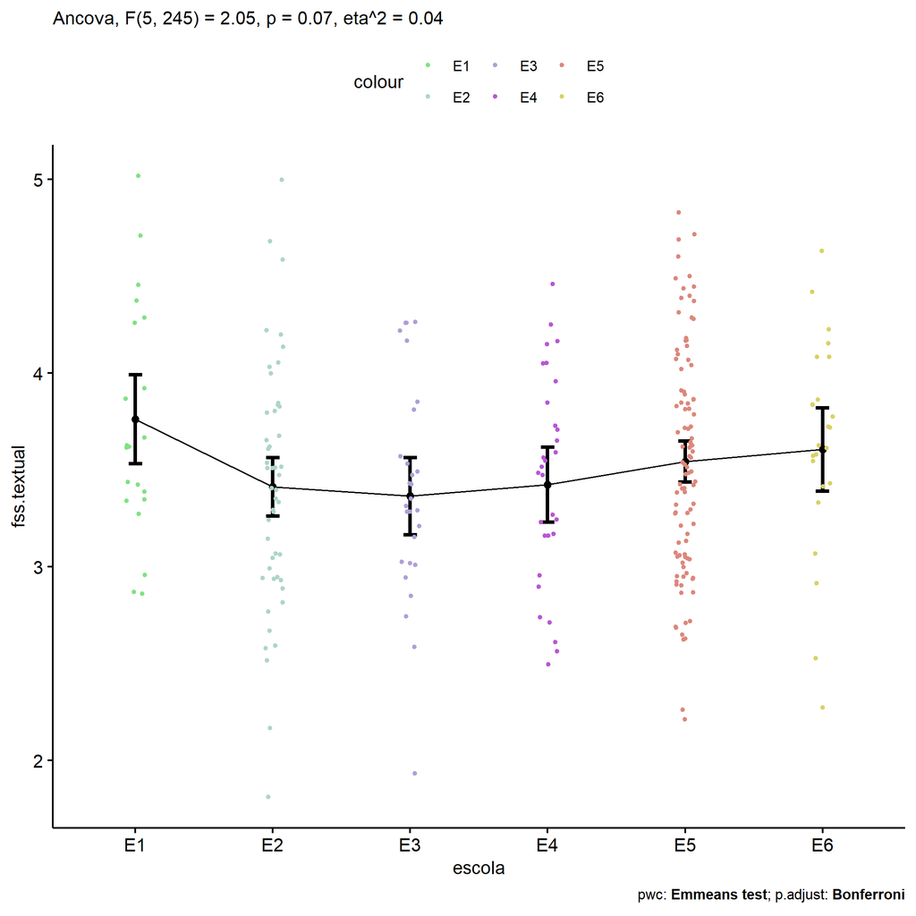

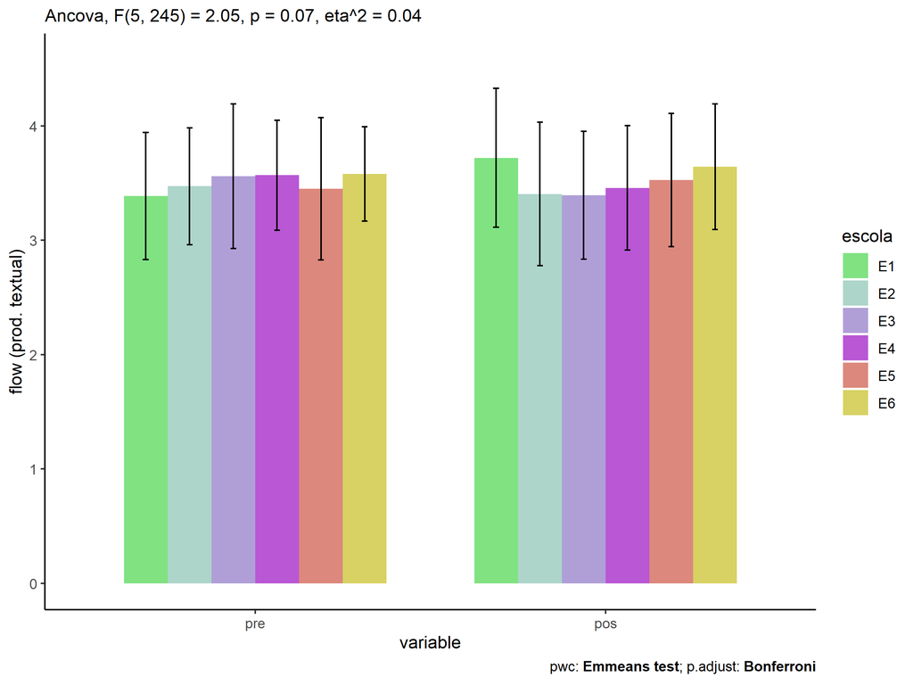

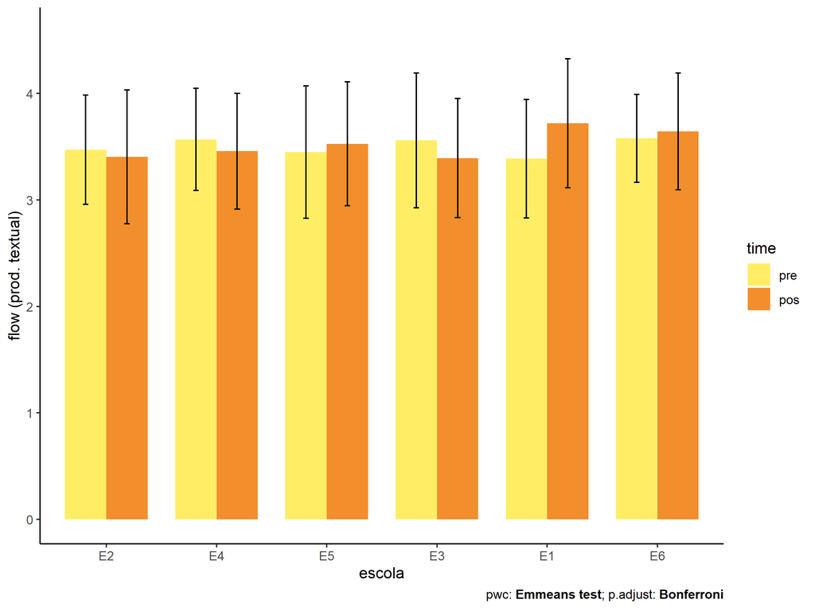

### factor: **zona.escola**

| var | zona.escola | n | M (pre) | SE (pre) | M (unadj) | SE (unadj) | M (adj) | SE (adj) |
| --- | --- | --- | --- | --- | --- | --- | --- | --- |
| fss.textual | Rural | 82 | 3.569 | 0.057 | 3.490 | 0.061 | 3.457 | 0.060 |
| fss.textual | Urbana | 170 | 3.449 | 0.045 | 3.516 | 0.046 | 3.532 | 0.042 |

| .y. | group1 | group2 | estimate | conf.low | conf.high | se | statistic | p | p.adj | p.adj.signif |
| --- | --- | --- | --- | --- | --- | --- | --- | --- | --- | --- |
| fss.textual | Urbana | Rural | 0.075 | -0.069 | 0.219 | 0.073 | 1.021 | 0.308 | 0.308 | ns |
| dfs.textual | Urbana | Rural | -0.120 | -0.268 | 0.028 | 0.075 | -1.594 | 0.112 | 0.112 | ns |

| .y. | zona.escola | group1 | group2 | estimate | conf.low | conf.high | se | statistic | p | p.adj | p.adj.signif |
| --- | --- | --- | --- | --- | --- | --- | --- | --- | --- | --- | --- |
| flow.textual | Urbana | pre | pos | -0.067 | -0.189 | 0.055 | 0.062 | -1.080 | 0.281 | 0.281 | ns |
| flow.textual | Rural | pre | pos | 0.078 | -0.098 | 0.254 | 0.090 | 0.875 | 0.382 | 0.382 | ns |

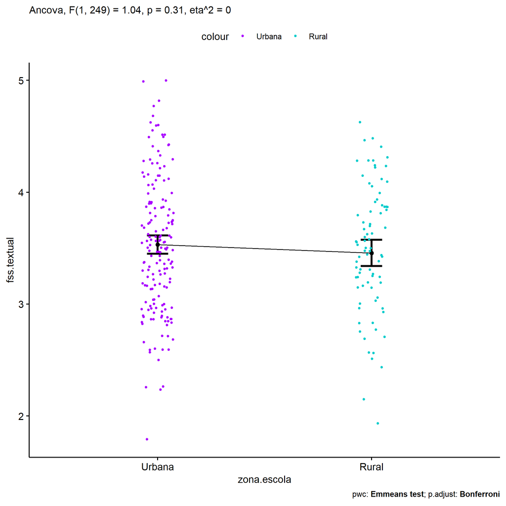

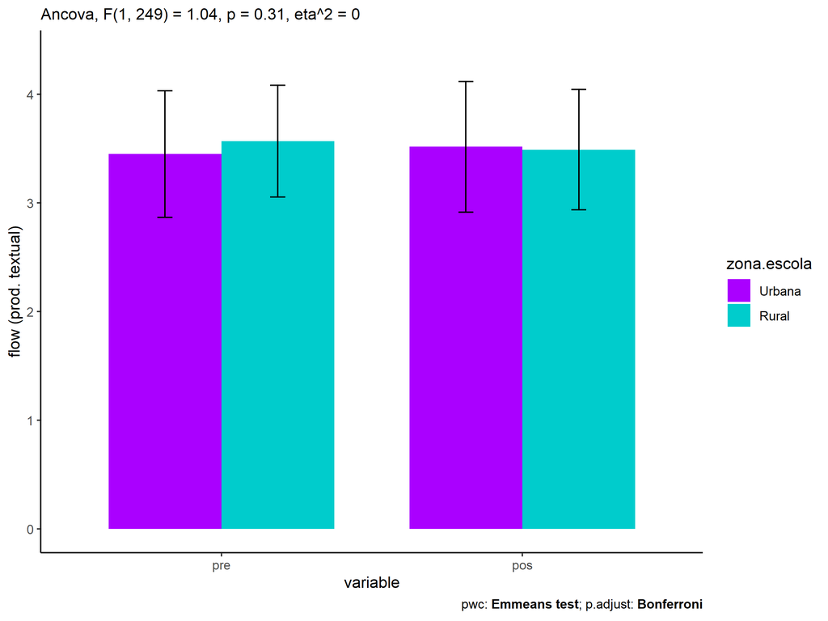

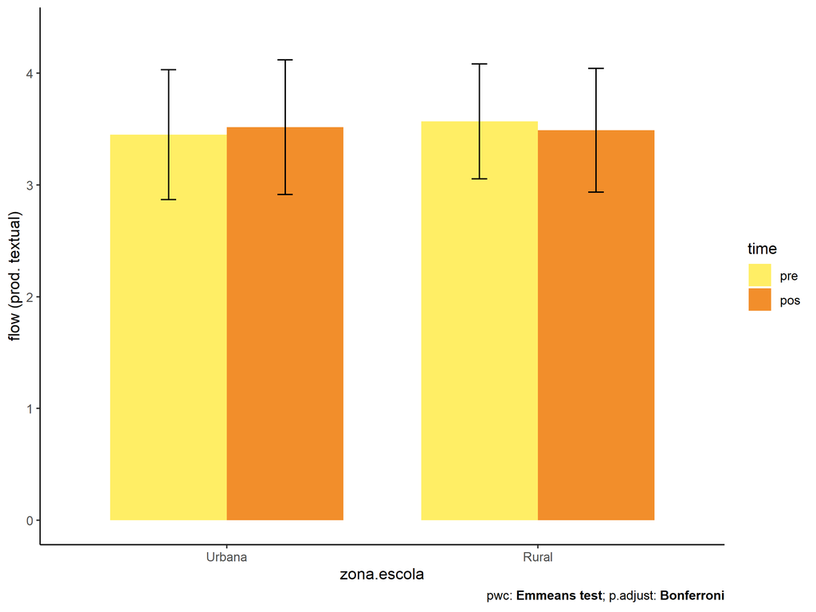